# Exploratory Data Analysis Of User Reviews In The Yelp Dataset

## Introduction to Dataset

Secondary Dataset: US economic time series - time series data about economic health indicators of the US

## Questions

1. What patterns can be found in user reviews and why do these patterns exist?
2. How do various internal and external factors affect business popularity?
3. How can we build a model to understand the sentiment expressed in a user review?

## 1.Analyzing Patterns In User Reviews

## Distribution Of User Ratings

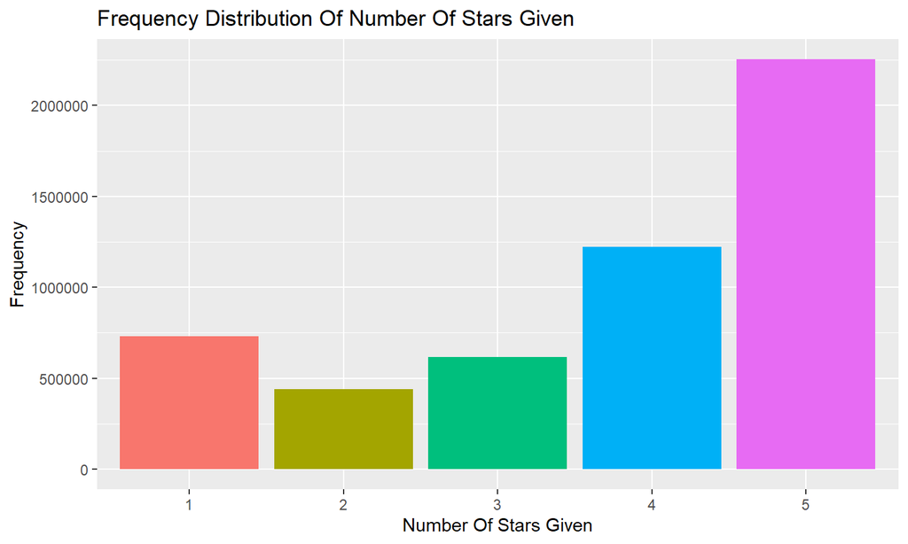

## Correlation Between Review Length And Rating

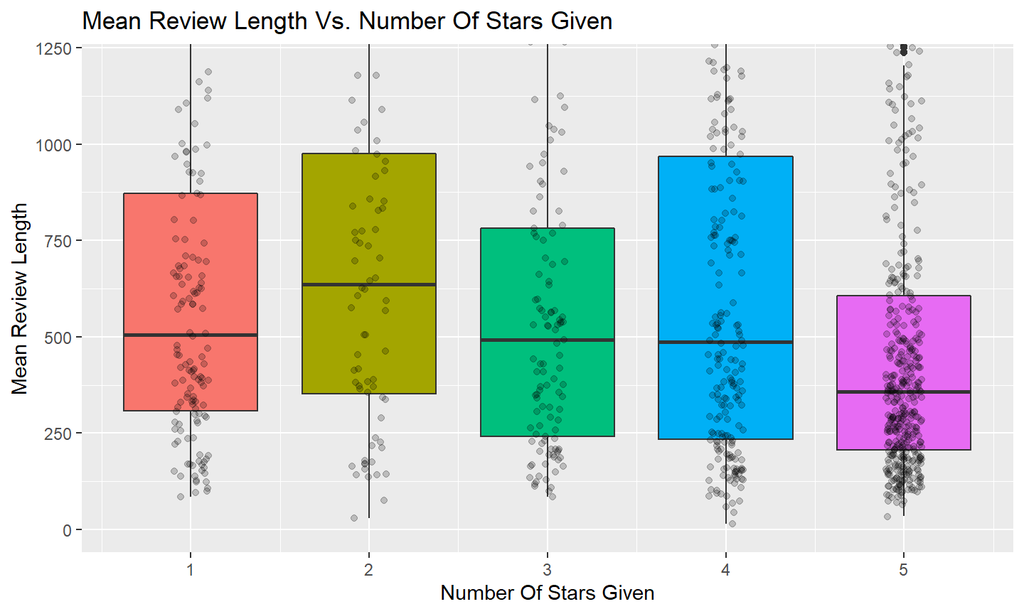

## User Ratings Across States

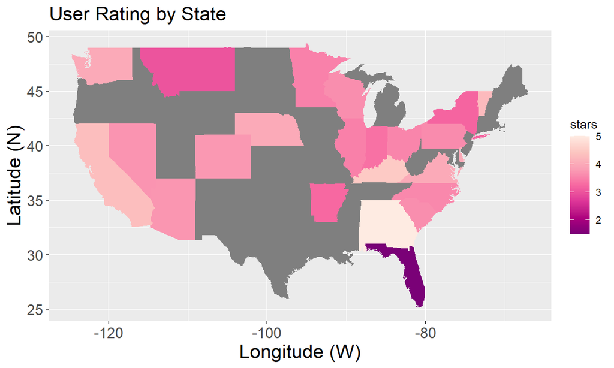

## User Ratings Across States

We have removed Shiny plots in order to render to a static HTML document.

## 2.Effects Of Internal And External Factors On Business Popularity

## Correlations Of Intraneous Variables With Business Popularity

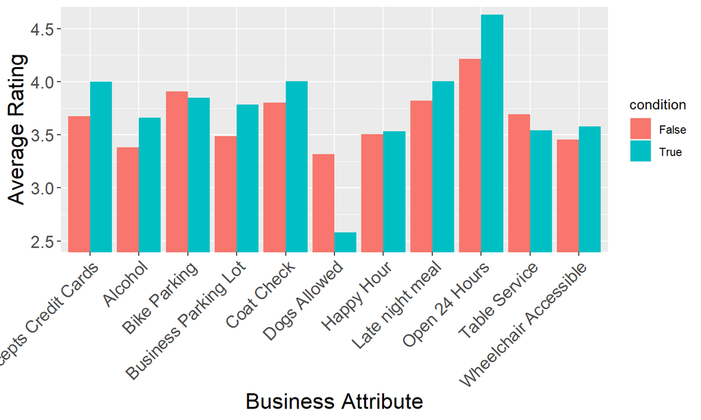

## A Case Study of Subway

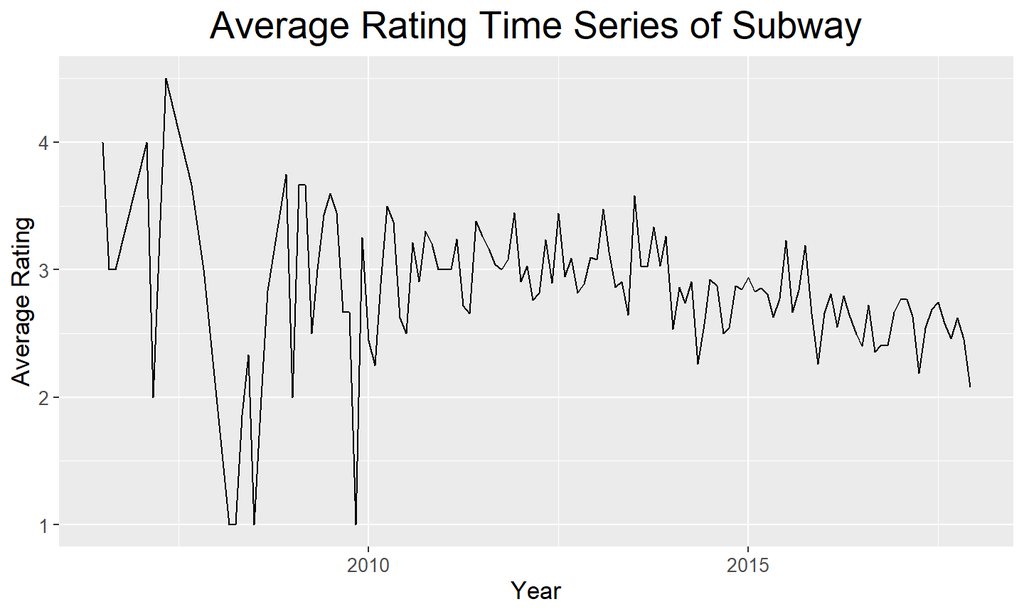

## A Case Study of Subway (with secondary data)

[figure not shown]

## Business size and extraneous economic factors

[figure not shown]

## 3.Sentiment Analysis Of Reviews

## Sentiment Analysis Of Reviews

**“Super simple place but amazing nonetheless. It’s been around since the 30’s and they still serve the same thing they started with: a bologna and salami sandwich with mustard. Staff was very helpful and friendly.”**

**“Service here is not great, it felt like they had forgotten about us and that they didn’t care about the service as everything came out one at a time. The Momofuko ramen was awful. It was bland and mushy. After a few bites, I couldn’t handle eating anymore. Momofuko is not the place to go if you want real ramen. I’ve had better experience with instant noodles.”**

## Sentiment Analysis Of Reviews

- **Objective**: Given the text of a user review, predict if it is a positive or a negative review.
- **Supervised machine learning** an obvious solution
- Problem: **Feature Extraction**
  - How do we convert the text of a review into features that can be used by a machine learning algorithm?

## Bag-Of-Words Approach

- Solution: Use the **relative frequencies** of words as features
- Term Frequency-Inverse Document Frequency(**TF-IDF**): \[tfidf(t, r, R) = \frac{f_{t,r}}{\sum_{t' \in r}{f_{t', r}}} \cdot \log\left(\frac{N}{|r \in R: t \in R|}\right)\]
  - \(f_{t, d}\): the number of times that term \(t\) occurs in review \(r\).
  - \(N\): total number of reviews
  - \(|r \in R: t \in R|\): number of reviews where the term \(t\) appears

## Logistic Regression

- Converted each review to a TF-IDF vector of the most commonly occurring 2000 words.
- Used a subset of our review data as training data to train a **logistic regression** model.
- Analyzed the **most important** words (the words corresponding to the most positive and most negative weights in the model).

## Most Important Words

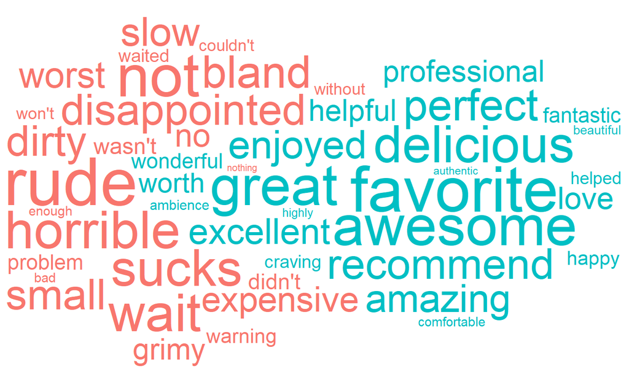